# Occupational Wage Data

Objective: explore how the average salary amongst professions have changed over time.

## Loading the data

```r
str(oes)
```

```
 num [1:22, 1:15] 70800 50580 60350 56330 49710 ...
 - attr(*, "dimnames")=List of 2
  ..$ : chr [1:22] "Management" "Business Operations" "Computer Science" "Architecture/Engineering" ...
  ..$ : chr [1:15] "2001" "2002" "2003" "2004" ...
```

22 Occupation Observations 15 Measurements of Average Income from 2001-2016

## Initial exploration of the data

```r
head(oes)
```

```
                           2001  2002  2003  2004  2005  2006  2007   2008   2010   2011   2012   2013   2014   2015   2016
Management                70800 78870 83400 87090 88450 91930 96150 100310 105440 107410 108570 110550 112490 115020 118020
Business Operations       50580 53350 56000 57120 57930 60000 62410  64720  67690  68740  69550  71020  72410  73800  75070
Computer Science          60350 61630 64150 66370 67100 69240 72190  74500  77230  78730  80180  82010  83970  86170  87880
Architecture/Engineering  56330 58020 60390 63060 63910 66190 68880  71430  75550  77120  79000  80100  81520  82980  84300
Life/Physical/Social Sci. 49710 52380 54930 57550 58030 59660 62020  64280  66390  67470  68360  69400  70070  71220  72930
Community Services        34190 34630 35800 37050 37530 39000 40540  41790  43180  43830  44240  44710  45310  46160  47200
```

```r
summary(oes)
```

```
      2001            2002            2003            2004            2005            2006            2007            2008             2010
 Min.   :16720   Min.   :17180   Min.   :17400   Min.   :17620   Min.   :17840   Min.   :18430   Min.   :19440   Min.   : 20220   Min.   : 21240
 1st Qu.:26728   1st Qu.:27393   1st Qu.:27858   1st Qu.:28535   1st Qu.:29043   1st Qu.:29688   1st Qu.:30810   1st Qu.: 31643   1st Qu.: 32863
 Median :34575   Median :35205   Median :36180   Median :37335   Median :37790   Median :39030   Median :40235   Median : 41510   Median : 42995
 Mean   :37850   Mean   :39701   Mean   :41018   Mean   :42275   Mean   :42775   Mean   :44329   Mean   :46074   Mean   : 47763   Mean   : 49758
 3rd Qu.:49875   3rd Qu.:53108   3rd Qu.:55733   3rd Qu.:57443   3rd Qu.:58005   3rd Qu.:59915   3rd Qu.:62313   3rd Qu.: 64610   3rd Qu.: 67365
 Max.   :70800   Max.   :78870   Max.   :83400   Max.   :87090   Max.   :88450   Max.   :91930   Max.   :96150   Max.   :100310   Max.   :105440
      2011             2012             2013             2014             2015             2016
 Min.   : 21430   Min.   : 21380   Min.   : 21580   Min.   : 21980   Min.   : 22850   Min.   : 23850
 1st Qu.: 33430   1st Qu.: 33795   1st Qu.: 34120   1st Qu.: 34718   1st Qu.: 35425   1st Qu.: 36350
 Median : 43610   Median : 44055   Median : 44565   Median : 45265   Median : 46075   Median : 46945
 Mean   : 50555   Mean   : 51077   Mean   : 51800   Mean   : 52643   Mean   : 53785   Mean   : 55117
 3rd Qu.: 68423   3rd Qu.: 69253   3rd Qu.: 70615   3rd Qu.: 71825   3rd Qu.: 73155   3rd Qu.: 74535
 Max.   :107410   Max.   :108570   Max.   :110550   Max.   :112490   Max.   :115020   Max.   :118020
```

No NA values exist in the data. The variables within this data are comparable to one another and don’t have to be scaled. There is no categorical variables within this data.

## Hierarchical clustering: Occupation trees

We will build a dendrogram of occupations based on their yearly average salaries and propose clusters using a height of 100,000.

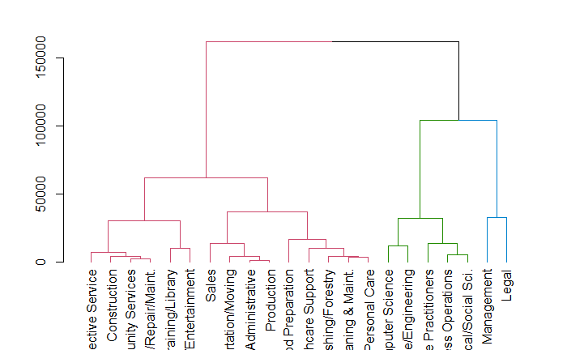

```r
# Calculate euclidean distance between the occupations
dist_oes <- dist(oes, method = "euclidean")
# Generate an average linkage analysis
hc_oes <- hclust(dist_oes, method = "average")
# Create a dendrogram object from the hclust variable
dend_oes <- as.dendrogram(hc_oes)
# Color branches by cluster formed from the cut at a height of 100000
dend_colored <- color_branches(dend_oes, h = 100000)
# Plot the colored dendrogram
plot(dend_colored)
```

Based on the dendrogram it may be reasonable to start with the three clusters formed at a height of 100,000. The members of these clusters appear to be tightly grouped but different from one another. Let’s continue this exploration.

## Hierarchical clustering: Preparing for exploration

Now we have created a potential clustering for the oes data, we want to explore these clusters with ggplot2. In order to do so, we will need to process the oes data matrix into a tidy data frame with each occupation assigned its cluster.

```r
# Use rownames_to_column to move the rownames into a column of the data frame
df_oes <- rownames_to_column(as.data.frame(oes), var = 'occupation')
# Create a cluster assignment vector at h = 100,000
cut_oes <- cutree(hc_oes, h = 100000)
# Generate the segmented oes dataframe
clust_oes <- mutate(df_oes, cluster = cut_oes)
# Create a tidy data frame by gathering the year and values into two columns
gathered_oes <- gather(data = clust_oes,
                       key = year,
                       value = mean_salary,
                       -occupation, -cluster)
head(gathered_oes)
```

|  | occupation | cluster | year | mean_salary |
| --- | --- | --- | --- | --- |
| 1 | Management | 1 | 2001 | 70800 |
| 2 | Business Operations | 2 | 2001 | 50580 |
| 3 | Computer Science | 2 | 2001 | 60350 |
| 4 | Architecture/Engineering | 2 | 2001 | 56330 |
| 5 | Life/Physical/Social Sci. | 2 | 2001 | 49710 |
| 6 | Community Services | 3 | 2001 | 34190 |

```r
tail(gathered_oes)
```

|  | occupation | cluster | year | mean_salary |
| --- | --- | --- | --- | --- |
| 325 | Office Administrative | 3 | 2016 | 37260 |
| 326 | Farming/Fishing/Forestry | 3 | 2016 | 27810 |
| 327 | Construction | 3 | 2016 | 48900 |
| 328 | Installation/Repair/Maint. | 3 | 2016 | 46690 |
| 329 | Production | 3 | 2016 | 37190 |
| 330 | Transportation/Moving | 3 | 2016 | 36070 |

## Hierarchical clustering: Plotting occupational clusters

Now we can explore the results of this hierarchical clustering work.

```r
# View the clustering assignments by sorting the cluster assignment vector
sort(cut_oes)
```

```
                Management                      Legal        Business Operations           Computer Science   Architecture/Engineering
                         1                          1                          2                          2                          2
 Life/Physical/Social Sci.   Healthcare Practitioners         Community Services Education/Training/Library  Arts/Design/Entertainment
                         2                          2                          3                          3                          3
        Healthcare Support         Protective Service           Food Preparation  Grounds Cleaning & Maint.              Personal Care
                         3                          3                          3                          3                          3
                     Sales      Office Administrative   Farming/Fishing/Forestry               Construction Installation/Repair/Maint.
                         3                          3                          3                          3                          3
                Production      Transportation/Moving
                         3                          3
```

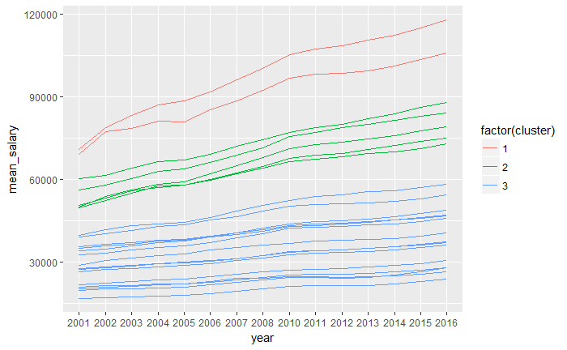

```r
# Plot the relationship between mean_salary and year and color the lines by the assigned cluster
ggplot(gathered_oes, aes(x = year, y = mean_salary, color = factor(cluster))) +
    geom_line(aes(group = occupation))
```

From this work it looks like both Management & Legal professions (cluster 1) experienced the most rapid growth in these 15 years. Let’s see what we can get by exploring this data using k-means.

## K-means: Elbow analysis

We have used the dendrogram to propose a clustering that generated 3 trees. Now we will leverage the k-means elbow plot to propose the “best” number of clusters.

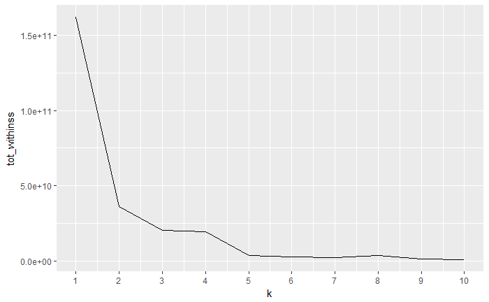

```r
# Use map_dbl to run many models with varying value of k (centers)
tot_withinss <- map_dbl(1:10,  function(k){
  model <- kmeans(x = oes, centers = k)
  model$tot.withinss
})
# Generate a data frame containing both k and tot_withinss
elbow_df <- data.frame(
  k = 1:10,
  tot_withinss = tot_withinss
)
# Plot the elbow plot
ggplot(elbow_df, aes(x = k, y = tot_withinss)) +
  geom_line() +
  scale_x_continuous(breaks = 1:10)
```

The elbow analysis proposes a different value of k: 2 instead of 3, let’s see what we can learn from Silhouette Width Analysis.

## K-means: Average Silhouette Widths

We use average silhouette widths to explore what the “best” value of k should be.

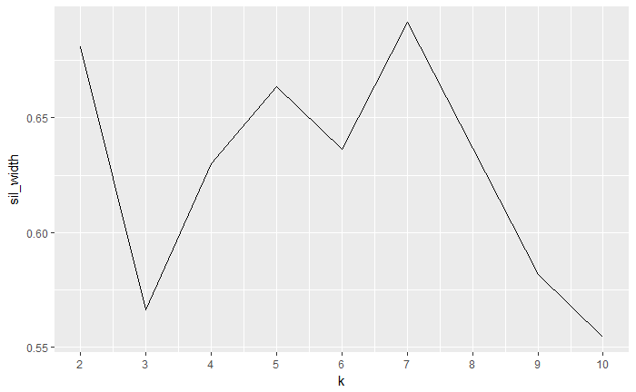

```r
# Use map_dbl to run many models with varying value of k
sil_width <- map_dbl(2:10,  function(k){
  model <- pam(oes, k = k)
  model$silinfo$avg.width
})
# Generate a data frame containing both k and sil_width
sil_df <- data.frame(
  k = 2:10,
  sil_width = sil_width
)
# Plot the relationship between k and sil_width
ggplot(sil_df, aes(x = k, y = sil_width)) +
  geom_line() +
  scale_x_continuous(breaks = 2:10)
```

It seems that this analysis results in another value of k, this time 7 is the top contender (although 2 comes very close).

## The “best” number of clusters

We ran three different methods for finding the optimal number of clusters and their assignments and we arrived with three different answers.

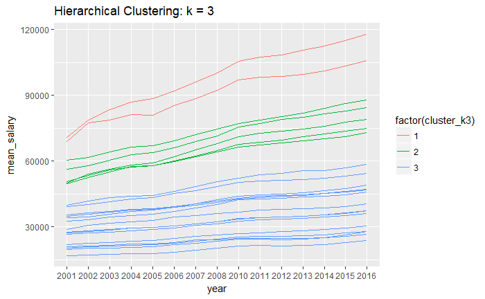

```r
model_k2 <- kmeans(x = oes, centers = 2)
model_k7 <- kmeans(x = oes, centers = 7)
# Generate the segmented oes dataframe
clust_oes <- mutate(df_oes, cluster_k3 = cut_oes, cluster_k2 = model_k2$cluster, cluster_k7 = model_k7$cluster)
# Create a tidy data frame by gathering the year and values into two columns
gathered_oes <- gather(data = clust_oes,
                       key = year,
                       value = mean_salary,
                       -occupation, -cluster_k3, -cluster_k2, -cluster_k7)
ggplot(gathered_oes, aes(x = year, y = mean_salary, color = factor(cluster_k3))) +
    geom_line(aes(group = occupation)) +
    ggtitle("Hierarchical Clustering: k = 3")
```

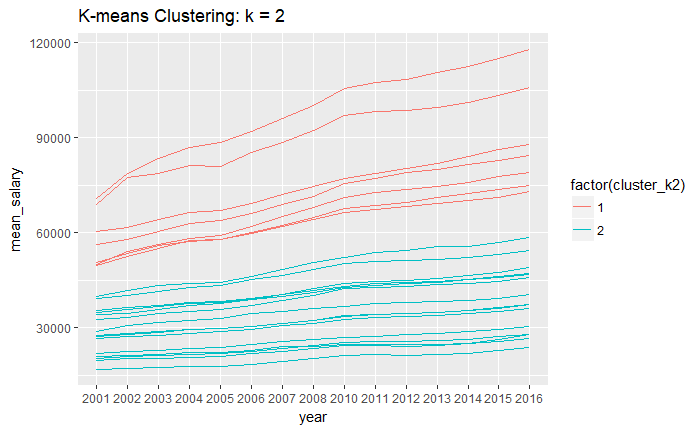

```r
ggplot(gathered_oes, aes(x = year, y = mean_salary, color = factor(cluster_k2))) +
    geom_line(aes(group = occupation)) +
    ggtitle("K-means Clustering: k = 2")
```

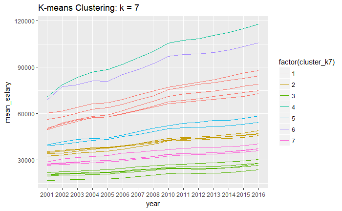

```r
ggplot(gathered_oes, aes(x = year, y = mean_salary, color = factor(cluster_k7))) +
    geom_line(aes(group = occupation)) +
    ggtitle("K-means Clustering: k = 7")
```

So… what is the “best” way to cluster the data ? All of the above are correct but the best way to cluster is highly dependent on how we would use this data after…